## HEADER

Who:KK

What: Naive base algoritham

Last edited: 2023-04-08

## CONTENTS

Introduction

Naive bayes

setup

## Introduction

Precision agriculture is in trend nowadays. It helps the farmers to get informed decision about the farming strategy.The science of training machines to learn and produce models for future predictions is widely used, and not for nothing. Agriculture plays a critical role in the global economy. With the continuing expansion of the human population understanding worldwide crop yield is central addressing food security challenges and reducing the impacts of climate change. Crop yield prediction is an important agricultural problem. The Agricultural yield primarily depends on weather conditions (rain, temperature, etc), pesticides and accurate information about history of crop yield is an important thing for making decisions related to agricultural risk management and future predictions.

N - ratio of Nitrogen content in soil P - ratio of Phosphorous content in soil K - ratio of Potassium content in soil temperature - temperature in degree Celsius humidity - relative humidity in % ph - ph value of the soil rainfall - rainfall in mm label - type of crop

Dataset source: https://www.kaggle.com/datasets/atharvaingle/crop-recommendation-dataset

## Naive bayes

Naive Bayes is a Supervised Machine Learning algorithm based on the Bayes Theorem that is used to solve classification problems by following a probabilistic approach. It is based on the idea that the predictor variables in a Machine Learning model are independent of each other. Meaning that the outcome of a model depends on a set of independent variables that have nothing to do with each other.

# Problem statement

Probabilities of which type of crops is suitable for cultivation based on the criteria such as ph, rainfall,temperature, etc…

## Setup

```r
setwd("C:/Users/DELL/Downloads")
getwd()
```

```
## [1] "C:/Users/DELL/Downloads"
```

set working directory to import our dataset

```r
crop <- read.csv("Crop_recommendation.csv")
```

Read the data into R environment

# Checking Null values

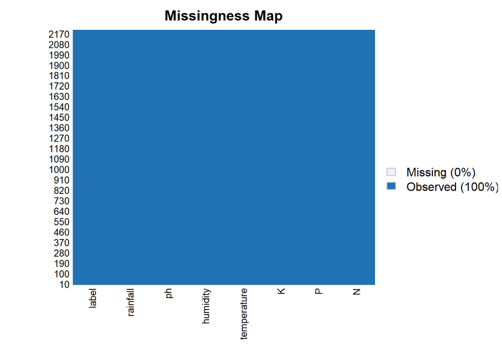

```r
library(Amelia)
missmap(crop)
```

# Explore the data

```r
summary(crop)
```

```
##        N                P                K           temperature
##  Min.   :  0.00   Min.   :  5.00   Min.   :  5.00   Min.   : 8.826
##  1st Qu.: 21.00   1st Qu.: 28.00   1st Qu.: 20.00   1st Qu.:22.769
##  Median : 37.00   Median : 51.00   Median : 32.00   Median :25.599
##  Mean   : 50.55   Mean   : 53.36   Mean   : 48.15   Mean   :25.616
##  3rd Qu.: 84.25   3rd Qu.: 68.00   3rd Qu.: 49.00   3rd Qu.:28.562
##  Max.   :140.00   Max.   :145.00   Max.   :205.00   Max.   :43.675
##     humidity           ph           rainfall         label
##  Min.   :14.26   Min.   :3.505   Min.   : 20.21   Length:2200
##  1st Qu.:60.26   1st Qu.:5.972   1st Qu.: 64.55   Class :character
##  Median :80.47   Median :6.425   Median : 94.87   Mode  :character
##  Mean   :71.48   Mean   :6.469   Mean   :103.46
##  3rd Qu.:89.95   3rd Qu.:6.924   3rd Qu.:124.27
##  Max.   :99.98   Max.   :9.935   Max.   :298.56
```

```r
names(crop)
```

```
## [1] "N"           "P"           "K"           "temperature" "humidity"
## [6] "ph"          "rainfall"    "label"
```

# Checking the correlation for pairwise among all the predicators in the dataset.

```r
cor(crop[ , -8])
```

```
##                       N           P           K temperature     humidity
## N            1.00000000 -0.23145958 -0.14051184  0.02650380  0.190688379
## P           -0.23145958  1.00000000  0.73623222 -0.12754113 -0.118734116
## K           -0.14051184  0.73623222  1.00000000 -0.16038713  0.190858861
## temperature  0.02650380 -0.12754113 -0.16038713  1.00000000  0.205319677
## humidity     0.19068838 -0.11873412  0.19085886  0.20531968  1.000000000
## ph           0.09668285 -0.13801889 -0.16950310 -0.01779502 -0.008482539
## rainfall     0.05902022 -0.06383905 -0.05346135 -0.03008378  0.094423053
##                       ph    rainfall
## N            0.096682846  0.05902022
## P           -0.138018893 -0.06383905
## K           -0.169503098 -0.05346135
## temperature -0.017795017 -0.03008378
## humidity    -0.008482539  0.09442305
## ph           1.000000000 -0.10906948
## rainfall    -0.109069484  1.00000000
```

```r
library(e1071) #for naive bayes algoritham
library(caret) #for data preprocessing
library(caTools) # split the data for train and test
```

# split the data for test and train

```r
set.seed(1)
split <- sample.split(crop$label, SplitRatio = 0.7)
train_data <- subset(crop, split == "TRUE")
test_data <- subset(crop, split =="FALSE")
```

# Deploy the naive bayes model

```r
set.seed(123) # For reproduceability
result <- naiveBayes(label ~ ., data = train_data, family = "multinomial")
result
```

```
##
## Naive Bayes Classifier for Discrete Predictors
##
## Call:
## naiveBayes.default(x = X, y = Y, laplace = laplace, family = "multinomial")
##
## A-priori probabilities:
## Y
##       apple      banana   blackgram    chickpea     coconut      coffee
##  0.04545455  0.04545455  0.04545455  0.04545455  0.04545455  0.04545455
##      cotton      grapes        jute kidneybeans      lentil       maize
##  0.04545455  0.04545455  0.04545455  0.04545455  0.04545455  0.04545455
##       mango   mothbeans    mungbean   muskmelon      orange      papaya
##  0.04545455  0.04545455  0.04545455  0.04545455  0.04545455  0.04545455
##  pigeonpeas pomegranate        rice  watermelon
##  0.04545455  0.04545455  0.04545455  0.04545455
##
## Conditional probabilities:
##              N
## Y                  [,1]     [,2]
##   apple        20.47143 11.46099
##   banana      101.34286 11.11454
##   blackgram    40.01429 12.97656
##   chickpea     39.38571 11.69577
##   coconut      22.31429 12.39862
##   coffee      100.84286 11.78015
##   cotton      118.01429 11.09053
##   grapes       23.10000 12.72923
##   jute         77.67143 10.35419
##   kidneybeans  21.11429 11.36170
##   lentil       19.71429 12.22630
##   maize        78.50000 12.13182
##   mango        18.87143 11.84798
##   mothbeans    19.57143 10.83683
##   mungbean     21.54286 11.31715
##   muskmelon   100.25714 11.78268
##   orange       19.50000 12.54413
##   papaya       49.08571 12.08753
##   pigeonpeas   20.71429 11.41718
##   pomegranate  19.24286 12.08477
```

[output cut: 137 more lines]

```
##   grapes       69.55849  3.117604
##   jute        174.37404 14.559620
##   kidneybeans 104.30965 25.527117
##   lentil       45.13603  5.978576
##   maize        84.81618 15.552570
##   mango        94.66879  3.288246
##   mothbeans    50.65568 13.903725
##   mungbean     48.22746  6.723748
##   muskmelon    24.48847  2.838499
##   orange      110.27951  5.975064
##   papaya      146.18454 64.691531
##   pigeonpeas  149.63188 32.741976
##   pomegranate 107.48176  2.701954
##   rice        235.86817 34.346133
##   watermelon   51.22960  5.862716
```

# predict the model

```r
predictions <- predict(result, newdata = test_data)
```

# confusion matrix to check the accuracy of the model

```r
cm <- table(test_data$label, predictions)
cm
```

```
##              predictions
##               apple banana blackgram chickpea coconut coffee cotton grapes jute
##   apple          30      0         0        0       0      0      0      0    0
##   banana          0     30         0        0       0      0      0      0    0
##   blackgram       0      0        30        0       0      0      0      0    0
##   chickpea        0      0         0       30       0      0      0      0    0
##   coconut         0      0         0        0      30      0      0      0    0
##   coffee          0      0         0        0       0     30      0      0    0
##   cotton          0      0         0        0       0      0     30      0    0
##   grapes          0      0         0        0       0      0      0     30    0
##   jute            0      0         0        0       0      0      0      0   30
##   kidneybeans     0      0         0        0       0      0      0      0    0
##   lentil          0      0         0        0       0      0      0      0    0
##   maize           0      0         0        0       0      0      1      0    0
##   mango           0      0         0        0       0      0      0      0    0
##   mothbeans       0      0         0        0       0      0      0      0    0
##   mungbean        0      0         0        0       0      0      0      0    0
##   muskmelon       0      0         0        0       0      0      0      0    0
##   orange          0      0         0        0       0      0      0      0    0
##   papaya          0      0         0        0       0      0      0      0    0
##   pigeonpeas      0      0         0        0       0      0      0      0    0
##   pomegranate     0      0         0        0       0      0      0      0    0
##   rice            0      0         0        0       0      0      0      0    4
##   watermelon      0      0         0        0       0      0      0      0    0
##              predictions
##               kidneybeans lentil maize mango mothbeans mungbean muskmelon
##   apple                 0      0     0     0         0        0         0
##   banana                0      0     0     0         0        0         0
##   blackgram             0      0     0     0         0        0         0
##   chickpea              0      0     0     0         0        0         0
##   coconut               0      0     0     0         0        0         0
##   coffee                0      0     0     0         0        0         0
##   cotton                0      0     0     0         0        0         0
##   grapes                0      0     0     0         0        0         0
##   jute                  0      0     0     0         0        0         0
##   kidneybeans          30      0     0     0         0        0         0
##   lentil                0     30     0     0         0        0         0
##   maize                 0      0    29     0         0        0         0
##   mango                 0      0     0    30         0        0         0
##   mothbeans             0      0     0     0        30        0         0
```

[output cut: 17 more lines]

```
##   grapes           0      0          0           0    0          0
##   jute             0      0          0           0    0          0
##   kidneybeans      0      0          0           0    0          0
##   lentil           0      0          0           0    0          0
##   maize            0      0          0           0    0          0
##   mango            0      0          0           0    0          0
##   mothbeans        0      0          0           0    0          0
##   mungbean         0      0          0           0    0          0
##   muskmelon        0      0          0           0    0          0
##   orange          30      0          0           0    0          0
##   papaya           0     30          0           0    0          0
##   pigeonpeas       0      0         30           0    0          0
##   pomegranate      0      0          0          30    0          0
##   rice             0      0          0           0   26          0
##   watermelon       0      0          0           0    0         30
```

# model evaluation

```r
confusionMatrix(cm)
```

```
## Confusion Matrix and Statistics
##
##              predictions
##               apple banana blackgram chickpea coconut coffee cotton grapes jute
##   apple          30      0         0        0       0      0      0      0    0
##   banana          0     30         0        0       0      0      0      0    0
##   blackgram       0      0        30        0       0      0      0      0    0
##   chickpea        0      0         0       30       0      0      0      0    0
##   coconut         0      0         0        0      30      0      0      0    0
##   coffee          0      0         0        0       0     30      0      0    0
##   cotton          0      0         0        0       0      0     30      0    0
##   grapes          0      0         0        0       0      0      0     30    0
##   jute            0      0         0        0       0      0      0      0   30
##   kidneybeans     0      0         0        0       0      0      0      0    0
##   lentil          0      0         0        0       0      0      0      0    0
##   maize           0      0         0        0       0      0      1      0    0
##   mango           0      0         0        0       0      0      0      0    0
##   mothbeans       0      0         0        0       0      0      0      0    0
##   mungbean        0      0         0        0       0      0      0      0    0
##   muskmelon       0      0         0        0       0      0      0      0    0
##   orange          0      0         0        0       0      0      0      0    0
##   papaya          0      0         0        0       0      0      0      0    0
##   pigeonpeas      0      0         0        0       0      0      0      0    0
##   pomegranate     0      0         0        0       0      0      0      0    0
##   rice            0      0         0        0       0      0      0      0    4
##   watermelon      0      0         0        0       0      0      0      0    0
##              predictions
##               kidneybeans lentil maize mango mothbeans mungbean muskmelon
##   apple                 0      0     0     0         0        0         0
##   banana                0      0     0     0         0        0         0
##   blackgram             0      0     0     0         0        0         0
##   chickpea              0      0     0     0         0        0         0
##   coconut               0      0     0     0         0        0         0
##   coffee                0      0     0     0         0        0         0
##   cotton                0      0     0     0         0        0         0
##   grapes                0      0     0     0         0        0         0
##   jute                  0      0     0     0         0        0         0
##   kidneybeans          30      0     0     0         0        0         0
##   lentil                0     30     0     0         0        0         0
##   maize                 0      0    29     0         0        0         0
```

[output cut: 96 more lines]

```
## Pos Pred Value                 1.00000            1.00000     0.86667
## Neg Pred Value                 1.00000            1.00000     1.00000
## Prevalence                     0.04545            0.04545     0.03939
## Detection Rate                 0.04545            0.04545     0.03939
## Detection Prevalence           0.04545            0.04545     0.04545
## Balanced Accuracy              1.00000            1.00000     0.99685
##                      Class: watermelon
## Sensitivity                    1.00000
## Specificity                    1.00000
## Pos Pred Value                 1.00000
## Neg Pred Value                 1.00000
## Prevalence                     0.04545
## Detection Rate                 0.04545
## Detection Prevalence           0.04545
## Balanced Accuracy              1.00000
```

# Result

The overall accuracy of the model is 99.24% which means our model correctly classified the observation of dataset.

95% confidence interval is a true population parameter. in our case the CI ranges between is 98.24% to 99.75%. which means true accuracy of the model lies between this range.

No information rate is a statstical bench mark that is used to evaluate the classification model which means prior probabilities of the most frequent classes in the dataset.the accuracy must be greater than no information which means making meaningful predictions which is useful for practical information.

Kappa value is the agreement between predicted value and actutal values and it ranges from -1 to 1. in general the value below 0.4 indicates poor agreement and and value above 0.8 indicates strong agreement.in our case 0.99 which is suggest the strong agreement.

The McNemar’s Test is a statistical test used to determine if there is a significant difference between two related proportions. It is often used in cases where the data is paired, such as in a before-and-after study, or when two classifiers are tested on the same dataset in our case its NA which means no paired sample tested or compared with the analysis.

p-value(accuracy > NIR) which is a null hypothesis testing.in our case value is(2.2e-16) less than alpha value(0.05) which means reject null hypotheis which suggest that our model accuracy is significant.

The statistics are also broken down by class. For each class, we have metrics such as sensitivity (the proportion of actual positives that are correctly identified), specificity (the proportion of actual negatives that are correctly identified), positive predictive value (the proportion of predicted positives that are true positives), and negative predictive value (the proportion of predicted negatives that are true negatives). We also have prevalence (the proportion of the data that belongs to each class), detection rate (the proportion of actual positives that are correctly identified), and detection prevalence (the proportion of predicted positives).

For example we will take apple the senistivity, specificity, ppv, and npv are all 1 which means our model correctly classifies as a apple. while prevalance and detection rate are equal prevalence proportion is 0.04545 and correctly detected 0.0454 which is a detection rate.it means it detected all our proportions correctly.detection prevalance is the proportion pf predicted positives which is 0.0454 which is accurate.and balanced accuracy is 1 which is perfect classification.